# **Problem Statement**

## Business Context

A sales forecast is a prediction of future sales revenue based on historical data, industry trends, and the status of the current sales pipeline. Businesses use the sales forecast to estimate weekly, monthly, quarterly, and annual sales totals. A company needs to make an accurate sales forecast as it adds value across an organization and helps the different verticals to chalk out their future course of action.

Forecasting helps an organization plan its sales operations by region and provides valuable insights to the supply chain team regarding the procurement of goods and materials. An accurate sales forecast process has many benefits which include improved decision-making about the future and reduction of sales pipeline and forecast risks. Moreover, it helps to reduce the time spent in planning territory coverage and establish benchmarks that can be used to assess trends in the future.

## Objective

SuperKart is a retail chain operating supermarkets and food marts across various tier cities, offering a wide range of products. To optimize its inventory management and make informed decisions around regional sales strategies, SuperKart wants to accurately forecast the sales revenue of its outlets for the upcoming quarter.

To operationalize these insights at scale, the company has partnered with a data science firm—not just to build a predictive model based on historical sales data, but to develop and deploy a robust forecasting solution that can be integrated into SuperKart’s decision-making systems and used across its network of stores.

## Data Description

The data contains the different attributes of the various products and stores.The detailed data dictionary is given below.

- **Product_Id** - unique identifier of each product, each identifier having two letters at the beginning followed by a number.
- **Product_Weight** - weight of each product
- **Product_Sugar_Content** - sugar content of each product like low sugar, regular and no sugar
- **Product_Allocated_Area** - ratio of the allocated display area of each product to the total display area of all the products in a store
- **Product_Type** - broad category for each product like meat, snack foods, hard drinks, dairy, canned, soft drinks, health and hygiene, baking goods, bread, breakfast, frozen foods, fruits and vegetables, household, seafood, starchy foods, others
- **Product_MRP** - maximum retail price of each product
- **Store_Id** - unique identifier of each store
- **Store_Establishment_Year** - year in which the store was established
- **Store_Size** - size of the store depending on sq. feet like high, medium and low
- **Store_Location_City_Type** - type of city in which the store is located like Tier 1, Tier 2 and Tier 3. Tier 1 consists of cities where the standard of living is comparatively higher than its Tier 2 and Tier 3 counterparts.
- **Store_Type** - type of store depending on the products that are being sold there like Departmental Store, Supermarket Type 1, Supermarket Type 2 and Food Mart
- **Product_Store_Sales_Total** - total revenue generated by the sale of that particular product in that particular store

# Keep Alive Code

```python
#import time
#while True:
#          print("Keeping Colab Active...")
#          time.sleep(500)  # Wait for 500 seconds before printing again
```

# **Installing and Importing the necessary libraries**

```python
#Installing the libraries with the specified versions
!pip install numpy==2.0.2 pandas==2.2.2 scikit-learn==1.6.1 matplotlib==3.10.0 seaborn==0.13.2 joblib==1.4.2 xgboost==2.1.4 requests==2.32.3 huggingface_hub==0.30.1 streamlit==1.45.0 -q
```

```
     ━━━━━━━━━━━━━━━━━━━━━━━━━━━━━━━━━━━━━━━━ 44.3/44.3 kB 3.2 MB/s eta 0:00:00
   ━━━━━━━━━━━━━━━━━━━━━━━━━━━━━━━━━━━━━━━━ 301.8/301.8 kB 14.3 MB/s eta 0:00:00
   ━━━━━━━━━━━━━━━━━━━━━━━━━━━━━━━━━━━━━━━━ 481.2/481.2 kB 32.2 MB/s eta 0:00:00
   ━━━━━━━━━━━━━━━━━━━━━━━━━━━━━━━━━━━━━━━━ 9.9/9.9 MB 63.5 MB/s eta 0:00:00
   ━━━━━━━━━━━━━━━━━━━━━━━━━━━━━━━━━━━━━━━━ 65.5/65.5 kB 5.7 MB/s eta 0:00:00
   ━━━━━━━━━━━━━━━━━━━━━━━━━━━━━━━━━━━━━━━━ 6.9/6.9 MB 88.3 MB/s eta 0:00:00
   ━━━━━━━━━━━━━━━━━━━━━━━━━━━━━━━━━━━━━━━━ 79.1/79.1 kB 6.1 MB/s eta 0:00:00
```

**Note:**

- After running the above cell, kindly restart the notebook kernel (for Jupyter Notebook) or runtime (for Google Colab) and run all cells sequentially from the next cell.
- On executing the above line of code, you might see a warning regarding package dependencies. This error message can be ignored as the above code ensures that all necessary libraries and their dependencies are maintained to successfully execute the code in this notebook.

```python
import warnings
warnings.filterwarnings("ignore")

# Libraries to help with reading and manipulating data
import numpy as np
import pandas as pd

# For splitting the dataset
from sklearn.model_selection import train_test_split

# Libaries to help with data visualization
import matplotlib.pyplot as plt
import seaborn as sns

# Removes the limit for the number of displayed columns
pd.set_option("display.max_columns", None)
# Sets the limit for the number of displayed rows
pd.set_option("display.max_rows", 100)


# Libraries different ensemble classifiers
from sklearn.ensemble import (
    BaggingRegressor,
    RandomForestRegressor,
    AdaBoostRegressor,
    GradientBoostingRegressor,
)
from xgboost import XGBRegressor
from sklearn.tree import DecisionTreeRegressor

# Libraries to get different metric scores
from sklearn.metrics import (
    confusion_matrix,
    accuracy_score,
    precision_score,
    recall_score,
    f1_score,
    mean_squared_error,
    mean_absolute_error,
    r2_score,
    mean_absolute_percentage_error
)

# To create the pipeline
from sklearn.compose import make_column_transformer
from sklearn.pipeline import make_pipeline,Pipeline

# To tune different models and standardize
from sklearn.model_selection import GridSearchCV,RandomizedSearchCV
from sklearn.preprocessing import StandardScaler,OneHotEncoder

# To serialize the model
import joblib

# os related functionalities
import os

# API request
import requests

# for hugging face space authentication to upload files
from huggingface_hub import login, HfApi

# Define random state = 42
RANDOM_STATE = 42
```

# **Loading the dataset**

```python
# This is specific to my google colab environment
from google.colab import drive

drive.mount('/content/drive',force_remount = True)

FOLDER_PATH = '/content/drive/MyDrive/Colab_Notebooks/SuperKart_Project/'

data_original = pd.read_csv(FOLDER_PATH+"SuperKart.csv")
```

```python
data = data_original.copy() #Make a copy of the original data
```

# **Data Overview** :

## Shape of the Dataset

```python
#Shape of the dataset

# print the total number of rows and coumns in the dataset
print(f"The dataset has {data.shape[0]} rows and {data.shape[1]} columns")
```

```
The dataset has 8763 rows and 12 columns
```

# Displaying the first and last 5 rows

```python
#Print the first and last five rows of the dataset
display(data.head(5))
display(data.tail(5))
```

|  | Product_Id | Product_Weight | Product_Sugar_Content | Product_Allocated_Area | Product_Type | Product_MRP | Store_Id | Store_Establishment_Year | Store_Size | Store_Location_City_Type | Store_Type | Product_Store_Sales_Total |
| --- | --- | --- | --- | --- | --- | --- | --- | --- | --- | --- | --- | --- |
| 0 | FD6114 | 12.66 | Low Sugar | 0.027 | Frozen Foods | 117.08 | OUT004 | 2009 | Medium | Tier 2 | Supermarket Type2 | 2842.40 |
| 1 | FD7839 | 16.54 | Low Sugar | 0.144 | Dairy | 171.43 | OUT003 | 1999 | Medium | Tier 1 | Departmental Store | 4830.02 |
| 2 | FD5075 | 14.28 | Regular | 0.031 | Canned | 162.08 | OUT001 | 1987 | High | Tier 2 | Supermarket Type1 | 4130.16 |
| 3 | FD8233 | 12.10 | Low Sugar | 0.112 | Baking Goods | 186.31 | OUT001 | 1987 | High | Tier 2 | Supermarket Type1 | 4132.18 |
| 4 | NC1180 | 9.57 | No Sugar | 0.010 | Health and Hygiene | 123.67 | OUT002 | 1998 | Small | Tier 3 | Food Mart | 2279.36 |

|  | Product_Id | Product_Weight | Product_Sugar_Content | Product_Allocated_Area | Product_Type | Product_MRP | Store_Id | Store_Establishment_Year | Store_Size | Store_Location_City_Type | Store_Type | Product_Store_Sales_Total |
| --- | --- | --- | --- | --- | --- | --- | --- | --- | --- | --- | --- | --- |
| 8758 | NC7546 | 14.80 | No Sugar | 0.016 | Health and Hygiene | 140.53 | OUT004 | 2009 | Medium | Tier 2 | Supermarket Type2 | 3806.53 |
| 8759 | NC584 | 14.06 | No Sugar | 0.142 | Household | 144.51 | OUT004 | 2009 | Medium | Tier 2 | Supermarket Type2 | 5020.74 |
| 8760 | NC2471 | 13.48 | No Sugar | 0.017 | Health and Hygiene | 88.58 | OUT001 | 1987 | High | Tier 2 | Supermarket Type1 | 2443.42 |
| 8761 | NC7187 | 13.89 | No Sugar | 0.193 | Household | 168.44 | OUT001 | 1987 | High | Tier 2 | Supermarket Type1 | 4171.82 |
| 8762 | FD306 | 14.73 | Low Sugar | 0.177 | Snack Foods | 224.93 | OUT002 | 1998 | Small | Tier 3 | Food Mart | 2186.08 |

## Checking 10 random rows

```python
#Check 10 random rows in the dataset
data.sample(n=10, random_state=1)
```

|  | Product_Id | Product_Weight | Product_Sugar_Content | Product_Allocated_Area | Product_Type | Product_MRP | Store_Id | Store_Establishment_Year | Store_Size | Store_Location_City_Type | Store_Type | Product_Store_Sales_Total |
| --- | --- | --- | --- | --- | --- | --- | --- | --- | --- | --- | --- | --- |
| 7441 | FD6870 | 12.76 | Low Sugar | 0.035 | Snack Foods | 158.59 | OUT004 | 2009 | Medium | Tier 2 | Supermarket Type2 | 3714.07 |
| 6355 | DR1429 | 17.54 | Low Sugar | 0.012 | Soft Drinks | 217.37 | OUT003 | 1999 | Medium | Tier 1 | Departmental Store | 5995.91 |
| 1271 | DR3999 | 12.02 | Regular | 0.013 | Soft Drinks | 201.24 | OUT003 | 1999 | Medium | Tier 1 | Departmental Store | 4419.17 |
| 3511 | FD3388 | 10.96 | Regular | 0.073 | Frozen Foods | 165.12 | OUT004 | 2009 | Medium | Tier 2 | Supermarket Type2 | 3440.23 |
| 1821 | FD2137 | 13.32 | Low Sugar | 0.076 | Fruits and Vegetables | 175.00 | OUT001 | 1987 | High | Tier 2 | Supermarket Type1 | 4175.82 |
| 5039 | FD3639 | 12.58 | reg | 0.093 | Starchy Foods | 159.98 | OUT004 | 2009 | Medium | Tier 2 | Supermarket Type2 | 3702.04 |
| 4924 | FD1669 | 14.99 | Low Sugar | 0.042 | Fruits and Vegetables | 160.10 | OUT003 | 1999 | Medium | Tier 1 | Departmental Store | 4249.88 |
| 6155 | FD938 | 7.39 | Low Sugar | 0.013 | Fruits and Vegetables | 119.24 | OUT002 | 1998 | Small | Tier 3 | Food Mart | 1695.67 |
| 1857 | FD3775 | 12.82 | Low Sugar | 0.076 | Fruits and Vegetables | 150.09 | OUT004 | 2009 | Medium | Tier 2 | Supermarket Type2 | 3553.53 |
| 5361 | NC6433 | 13.44 | No Sugar | 0.076 | Household | 137.65 | OUT004 | 2009 | Medium | Tier 2 | Supermarket Type2 | 3440.00 |

## Type of columns in the dataset

```python
#Print the data type of all columns in the dataset
data.info()
```

```
<class 'pandas.core.frame.DataFrame'>
RangeIndex: 8763 entries, 0 to 8762
Data columns (total 12 columns):
 #   Column                     Non-Null Count  Dtype
---  ------                     --------------  -----
 0   Product_Id                 8763 non-null   object
 1   Product_Weight             8763 non-null   float64
 2   Product_Sugar_Content      8763 non-null   object
 3   Product_Allocated_Area     8763 non-null   float64
 4   Product_Type               8763 non-null   object
 5   Product_MRP                8763 non-null   float64
 6   Store_Id                   8763 non-null   object
 7   Store_Establishment_Year   8763 non-null   int64
 8   Store_Size                 8763 non-null   object
 9   Store_Location_City_Type   8763 non-null   object
 10  Store_Type                 8763 non-null   object
 11  Product_Store_Sales_Total  8763 non-null   float64
dtypes: float64(4), int64(1), object(7)
memory usage: 821.7+ KB
```

## Statistical summary

```python
#Print the statistical summary of the data
data.describe(include='all').T
```

|  | count | unique | top | freq | mean | std | min | 25% | 50% | 75% | max |
| --- | --- | --- | --- | --- | --- | --- | --- | --- | --- | --- | --- |
| Product_Id | 8763 | 8763 | FD306 | 1 | NaN | NaN | NaN | NaN | NaN | NaN | NaN |
| Product_Weight | 8763.0 | NaN | NaN | NaN | 12.653792 | 2.21732 | 4.0 | 11.15 | 12.66 | 14.18 | 22.0 |
| Product_Sugar_Content | 8763 | 4 | Low Sugar | 4885 | NaN | NaN | NaN | NaN | NaN | NaN | NaN |
| Product_Allocated_Area | 8763.0 | NaN | NaN | NaN | 0.068786 | 0.048204 | 0.004 | 0.031 | 0.056 | 0.096 | 0.298 |
| Product_Type | 8763 | 16 | Fruits and Vegetables | 1249 | NaN | NaN | NaN | NaN | NaN | NaN | NaN |
| Product_MRP | 8763.0 | NaN | NaN | NaN | 147.032539 | 30.69411 | 31.0 | 126.16 | 146.74 | 167.585 | 266.0 |
| Store_Id | 8763 | 4 | OUT004 | 4676 | NaN | NaN | NaN | NaN | NaN | NaN | NaN |
| Store_Establishment_Year | 8763.0 | NaN | NaN | NaN | 2002.032751 | 8.388381 | 1987.0 | 1998.0 | 2009.0 | 2009.0 | 2009.0 |
| Store_Size | 8763 | 3 | Medium | 6025 | NaN | NaN | NaN | NaN | NaN | NaN | NaN |
| Store_Location_City_Type | 8763 | 3 | Tier 2 | 6262 | NaN | NaN | NaN | NaN | NaN | NaN | NaN |
| Store_Type | 8763 | 4 | Supermarket Type2 | 4676 | NaN | NaN | NaN | NaN | NaN | NaN | NaN |
| Product_Store_Sales_Total | 8763.0 | NaN | NaN | NaN | 3464.00364 | 1065.630494 | 33.0 | 2761.715 | 3452.34 | 4145.165 | 8000.0 |

## Unique value check

```python
#Check for unique values
data.nunique()
```

|  | 0 |
| --- | --- |
| Product_Id | 8763 |
| Product_Weight | 1113 |
| Product_Sugar_Content | 4 |
| Product_Allocated_Area | 228 |
| Product_Type | 16 |
| Product_MRP | 6100 |
| Store_Id | 4 |
| Store_Establishment_Year | 4 |
| Store_Size | 3 |
| Store_Location_City_Type | 3 |
| Store_Type | 4 |
| Product_Store_Sales_Total | 8668 |

**dtype:** int64

```python
#Print unique values in Product_Sugar_Content
print("Unique values in Product_Sugar_Content:", np.sort(data['Product_Sugar_Content'].unique()))

#Print unique values in Store_Id
print("Unique values in Store_Id:", np.sort(data['Store_Id'].unique()))

#Print unique values in Store_Establishment_Year
print("Unique values in Store_Establishment_Year:", np.sort(data['Store_Establishment_Year'].unique()))

#Print unique values in Store_Size
print("Unique values in Store_Size:", np.sort(data['Store_Size'].unique()))

#Print unique calues in Store_Location_City_Type
print("Unique values in Store_Location_City_Type:", np.sort(data['Store_Location_City_Type'].unique()))

#Print unique values in Store_Type
print("Unique values in Store_Type:", np.sort(data['Store_Type'].unique()))
```

```
Unique values in Product_Sugar_Content: ['Low Sugar' 'No Sugar' 'Regular' 'reg']
Unique values in Store_Id: ['OUT001' 'OUT002' 'OUT003' 'OUT004']
Unique values in Store_Establishment_Year: [1987 1998 1999 2009]
Unique values in Store_Size: ['High' 'Medium' 'Small']
Unique values in Store_Location_City_Type: ['Tier 1' 'Tier 2' 'Tier 3']
Unique values in Store_Type: ['Departmental Store' 'Food Mart' 'Supermarket Type1' 'Supermarket Type2']
```

## Duplicate value check

```python
#Check for Duplicate Values in the dataset
data.duplicated().sum()
```

```
np.int64(0)
```

## Missing value check

```python
#Check for Missing Values in the dataset
data.isnull().sum()
```

|  | 0 |
| --- | --- |
| Product_Id | 0 |
| Product_Weight | 0 |
| Product_Sugar_Content | 0 |
| Product_Allocated_Area | 0 |
| Product_Type | 0 |
| Product_MRP | 0 |
| Store_Id | 0 |
| Store_Establishment_Year | 0 |
| Store_Size | 0 |
| Store_Location_City_Type | 0 |
| Store_Type | 0 |
| Product_Store_Sales_Total | 0 |

**dtype:** int64

### **Dataset Observations**

- The dataset has 8763 rows and 12 columns
- We find 4 columns of float64 type, 1 column of int64 type and 7 columns of object type.
- There are no duplicate or missing values in the dataset.

#### Product Observations

- Product_Weight:
  - The average product weight is 12.65, with weights ranging from 4 to 22.
  - The distribution is relatively tight, with a standard deviation of ~2.22, suggesting most products are close in weight.
- Product_Sugar_Content:
  - There are 4 distinct sugar content levels - 'Low Sugar' 'No Sugar' 'Regular' 'reg'.
  - We may have to combine 'Regular' and 'reg' later.
  - The most frequent label is "Low Sugar", making up over half the products

  (4,885 out of 8,763)
- Product_Allocated_Area:
  - Values range from 0.004 to 0.298, with a mean of 0.069.
  - Most products occupy less than 0.1 units
- Product_Type:
  - The data includes 16 different product types.
  - The most common type is "Fruits and Vegetables", accounting for 1,249 entries (~14%).
- Product_MRP (Maximum Retail Price):
  - Product prices vary from 31 to 266, with an average price of 147.03.
  - This wide range suggests inclusion of both budget and premium products.

#### Key Observations:

- The dataset offers a rich blend of product diversity and store-level context, allowing for detailed market and operational analysis.
- Fruits and Vegetables, Low Sugar products, and mid-range prices dominate the product space.
- Most data is concentrated in medium-sized, Tier 2 city stores, particularly in Supermarket Type 2 formats.
- Sales data exhibits high variability, indicating opportunities for product optimization and store-specific marketing strategies.

# **Exploratory Data Analysis (EDA)**

## Univariate Analysis

```python
#Function to plot both histogram and boxplot

def histogram_boxplot(data, feature, figsize=(15, 10), kde=False, bins=None):
    """
    Boxplot and histogram combined

    data: dataframe
    feature: dataframe column
    figsize: size of figure (default (15,10))
    kde: whether to show the density curve (default False)
    bins: number of bins for histogram (default None)
    """
    f2, (ax_box2, ax_hist2) = plt.subplots(
        nrows=2,  # Number of rows of the subplot grid= 2
        sharex=True,  # x-axis will be shared among all subplots
        gridspec_kw={"height_ratios": (0.25, 0.75)},
        figsize=figsize,
    )  # creating the 2 subplots
    sns.boxplot(
        data=data, x=feature, ax=ax_box2, showmeans=True, color="violet"
    )  # boxplot will be created and a triangle will indicate the mean value of the column
    sns.histplot(
        data=data, x=feature, kde=True, ax=ax_hist2, bins=bins
    ) if bins else sns.histplot(
        data=data, x=feature, kde=True, ax=ax_hist2
    )  # For histogram

    # Calculate and plot mean and median only if the feature is numeric
    if pd.api.types.is_numeric_dtype(data[feature]):
      ax_hist2.axvline(
          data[feature].mean(), color="green", linestyle="--"
      )  # Add mean to the histogram
      ax_hist2.axvline(
          data[feature].median(), color="blue", linestyle="-"
      )  # Add median to the histogram
    else:
      #add mode
      ax_hist2.axvline(
          data[feature].mode()[0], color="blue", linestyle="-"
      )
```

```python
# function to create labeled barplots


def labeled_barplot(data, feature, perc=False, n=None):
    """
    Barplot with percentage at the top

    data: dataframe
    feature: dataframe column
    perc: whether to display percentages instead of count (default is False)
    n: displays the top n category levels (default is None, i.e., display all levels)
    """

    total = len(data[feature])  # length of the column
    count = data[feature].nunique()
    if n is None:
        plt.figure(figsize=(count + 2, 6))
    else:
        plt.figure(figsize=(n + 2, 6))

    plt.xticks(rotation=90, fontsize=15)
    ax = sns.countplot(
        data=data,
        x=feature,
        palette="Paired",
        order=data[feature].value_counts().index[:n],
    )

    for p in ax.patches:
        if perc == True:
            label = "{:.1f}%".format(
                100 * p.get_height() / total
            )  # percentage of each class of the category
        else:
            label = p.get_height()  # count of each level of the category

        x = p.get_x() + p.get_width() / 2  # width of the plot
        y = p.get_height()  # height of the plot

        ax.annotate(
            label,
            (x, y),
            ha="center",
            va="center",
            size=12,
            xytext=(0, 5),
            textcoords="offset points",
        )  # annotate the percentage

    plt.show()  # show the plot
```

### Product_Weight

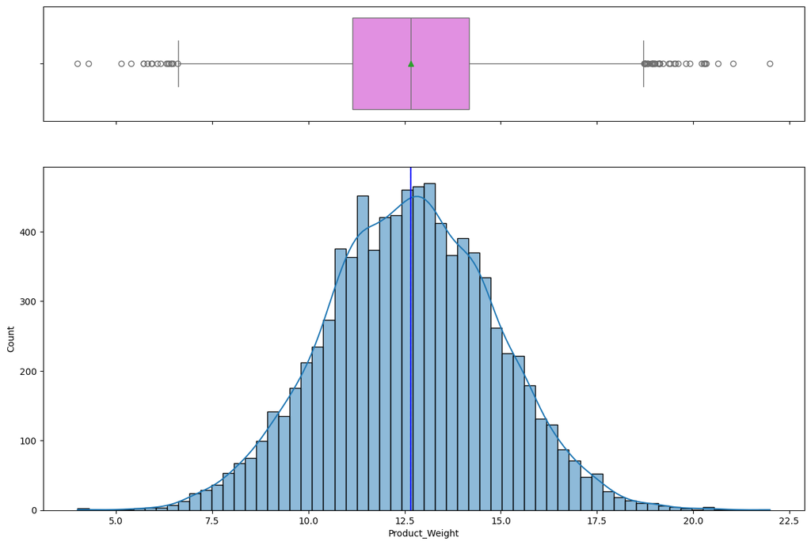

```python
histogram_boxplot(data, 'Product_Weight')
```

### Product_Allocated_Area

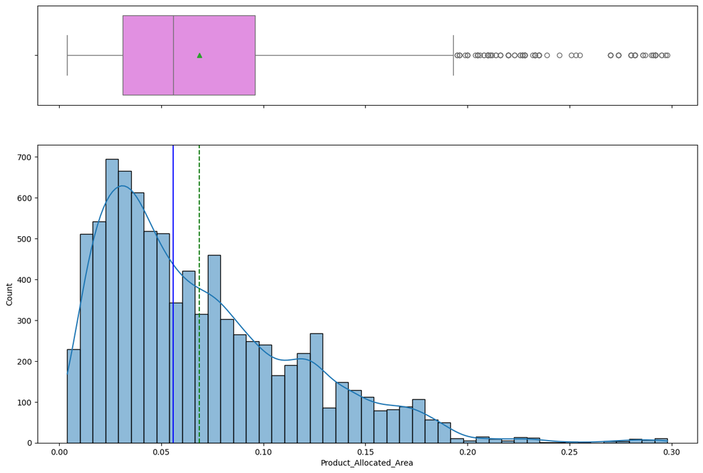

```python
histogram_boxplot(data, 'Product_Allocated_Area')
```

### Product_MRP

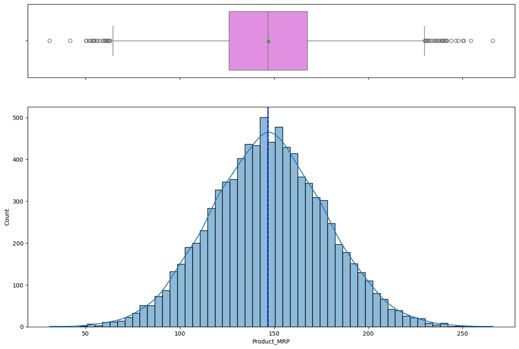

```python
histogram_boxplot(data, 'Product_MRP')
```

**Insights**

- Product_MRP is almost normally distributed,with most values lying between 100 and 200.
- The mean and median are very close.
- There are some outliers on both the lower and upper ends, but they are not extreme.
- This kind of distribution suggests well-calibrated pricing across the product line, with a focus around mid-range price points.

### Product_Store_Sales_Total

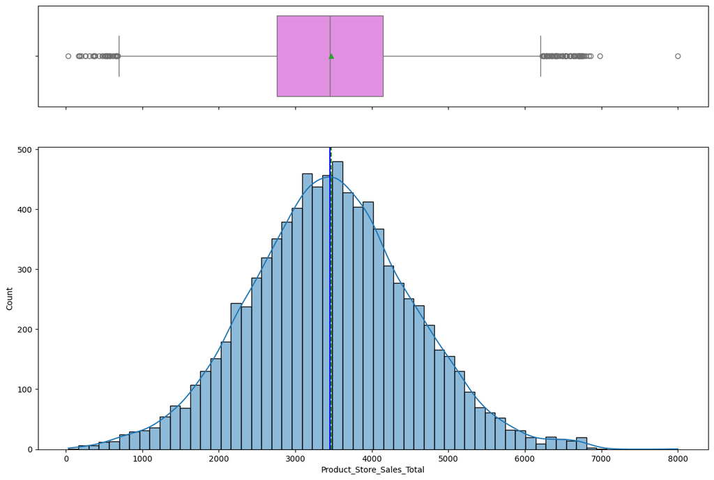

```python
histogram_boxplot(data, 'Product_Store_Sales_Total')
```

**Insights**

- Product_Store_Sales_Total is largely symmetrical and bell-shaped.
- The mean and median are very close.
- Outliers are observed on both ends (some unusually low and high sales).

### Product_Sugar_Content

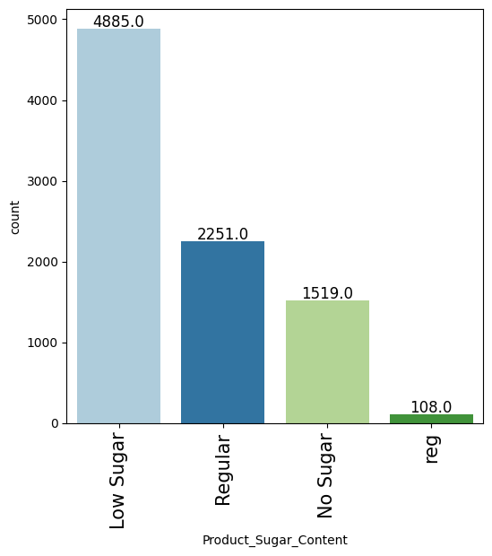

```python
labeled_barplot(data, 'Product_Sugar_Content')
```

**Insights**

- The chart clearly shows that "Low Sugar" products make up the largest portion of the dataset.
- Products labeled "Low Sugar" are the most common, followed by "Regular," then "No Sugar," with "reg" being a very small, almost negligible category in comparison.
- There is also a notable data inconsistency with the "Regular" and "reg" labels, which should be consolidated for accurate analysis (as noted earlier in analysis of unique values).
- "Low Sugar" products will still remain the largest portion (even after consolidating "Regular" and "reg").
- Overall, the data points towards a product assortment that heavily features low-sugar options. This could be a strategic focus on healthier options or could reflect a strong consumer demand for products with reduced sugar content.

### Product_Type

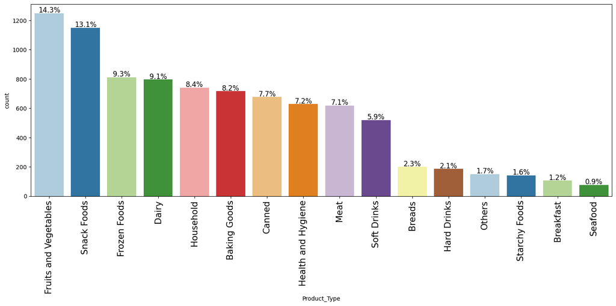

```python
labeled_barplot(data, 'Product_Type', perc=True)
```

**Insights**

- Fruits and Vegetables is the most prevalent product type with a count of 1,249 (14.3%).
- Snack Foods follows very closely as the second most common category with 1,149 items (13.1%).
- These two categories are clear leaders and represent a significant portion of the total product count, suggesting they are core categories for this business or dataset.
- Following the top two, there is a group of categories with substantial counts, ranging from approximately 600 to 800 items. These include:
  - Frozen Foods: 811
  - Dairy: 796
  - Household: 740
  - Baking Goods: 716
  - Canned: 677
  - Health and Hygiene: 628
  - Meat: 618
  - This tier represents the bulk of the remaining core product offerings.
- There is a noticeable drop-off in frequency after the "Meat" category.
- Soft Drinks stands alone with a count of 519.
- The remaining categories have significantly lower counts (200 or less), suggesting they are either less-stocked or more specialized/niche product types. These include:
  - Breads (200)
  - Hard Drinks (186)
  - Others (151)
  - Starchy Foods (141)
  - Breakfast (106)
  - Seafood is the least frequent category with only 76 items.
- The high counts in categories like "Fruits and Vegetables" and "Snack Foods" imply that these products likely require the most significant inventory and

prominent shelf space in a retail environment.

- These top categories are likely key drivers of foot traffic and sales. Marketing efforts, promotions, and cross-selling strategies could be heavily focused on these popular product types.
- The distribution shows a strong focus on essential food items (produce, snacks, dairy, frozen) and household goods. The lower counts in categories like "Seafood" or "Breakfast" could represent an opportunity for expansion or may be a deliberate strategy to focus on higher-turnover items.
- The "Others" category is relatively small (151 items). It indicates that most products have been successfully classified into meaningful categories.

### Store_Id

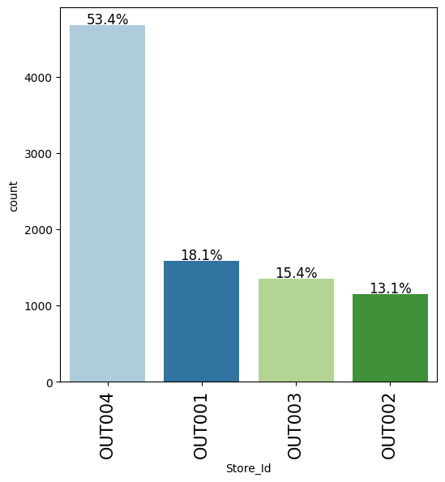

```python
labeled_barplot(data, 'Store_Id', perc=True)
```

**Insights**

- From the chart we can see the dominance of Store OUT004 (53.4%). These numbers are greater than the remaining stores combined.
- OUT004 has almost three times greater numbers than the next best store OUT001.
- The three stores OUT001, OUT002 & OUT003 form a distinct tier with minimal gap between them.
- The distribution is highly imbalanced and could be due to:
  - OUT004 could be a larger format store or a flagship store.
  - Better performance at OUT004 could be due to prime location, size, better strategy or management.
  - This might impact the model performance and its prediction accuracy for other less represented stores. The underlying reason has to be investigated for better business analysis, strategic planning, or data modeling.

### Store_Size

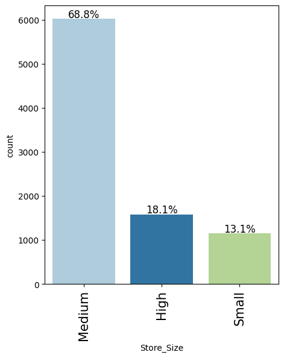

```python
labeled_barplot(data, 'Store_Size', perc=True)
```

**Insights**

- Medium sized stores are seen to dominate in this graph. More than two-thirds of the data are from this store size.
- This distribution also shows an imbalance. The number of medium sized stores are greater than three times the number of high-sized stores and more than five times the number of small-sized stores.
- The business's strategy could be to focus on medium sized stores.
- We probably should later focus on F1-score, Precision-Recall and not only on accuracy metrics.

### Store_Location_City_Type

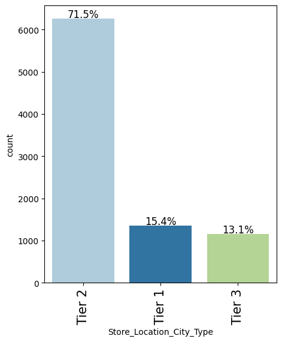

```python
labeled_barplot(data, 'Store_Location_City_Type', perc=True)
```

**Insights**

- We see the dominance of Tier 2 cities (71.5%) from the graph and also the imbalance it depicts.
- Data from the Tier 2 cities are nearly five times greater than those of Tier 1 and Tier 3 cities.
- Similar to Store_Size, we probably should later focus on F1-score, Precision-Recall and not only on accuracy metrics.

### Store_Type

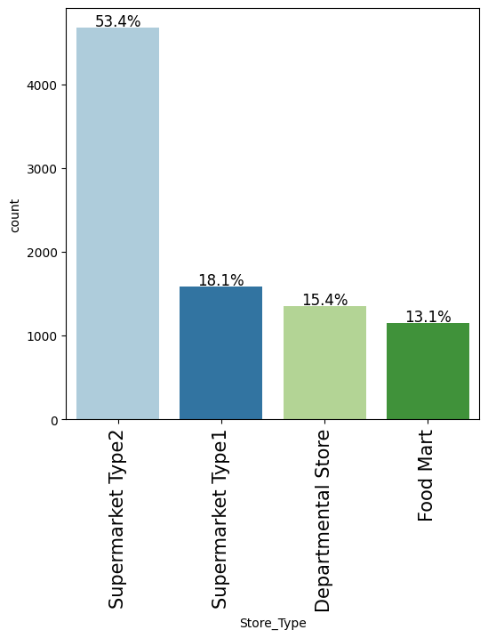

```python
labeled_barplot(data, 'Store_Type', perc=True)
```

**Insights**

- Supermarket Type2 is the dominant category here and accounts for 53.4%. This means more than half the data points fall under this single store type.
- The business structure could be to have Type2 super markets.
- The remaining three categories have smaller shares:
  - Supermarket Type1: 18.1%
  - Departmental Store: 15.4%
  - Food Mart: 13.1%
- Once again, the dataset is seen to be imbalanced.
- As before, it will be important to use evaluation metrics that are robust to class imbalance: F1-score, Precision, Recall to get a true sense of the performance across all store types.
- We might have to resort to using stratified sampling or using SMOTE to oversample minority class.

## Bivariate Analysis

### Correlation matrix

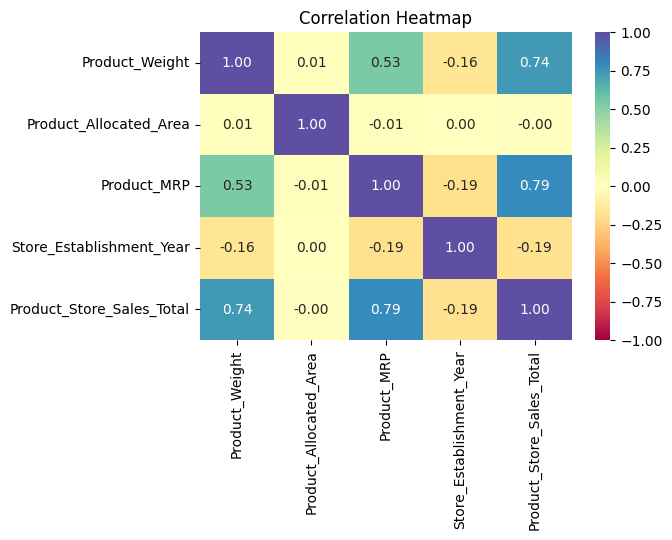

```python
# plot correlation on numeric columns
corr =  data.select_dtypes(include=['number']).corr()

plt.figure(figsize=(6,4))

sns.heatmap(corr, annot=True, vmin=-1, vmax=1, fmt=".2f", cmap="Spectral")

plt.title("Correlation Heatmap")
plt.show()
```

**Insights**

- We can observe few key relationships regarding what drives Product_Store_Sales_Total.
- Strongest Positive Correlations:
  - Product_MRP and Product_Store_Sales_Total (Correlation: 0.79): This is the strongest relationship on the map. The dark teal color highlights it visually.

  This is logical as more expensive products generate higher sales revenue.
  - Product_Weight and Product_Store_Sales_Total (Correlation: 0.74): This is another strong positive correlation. This might be because heavier items are often bulk goods or more substantial products that naturally have a higher price point.
  - Product_Weight and Product_MRP (Correlation: 0.53): This is a moderate positive correlation. Heavier products tend to have a higher MRP, suggesting that weight and price are linked, and both contribute to higher sales.
- Product_MRP and Product_Weight could be very strong predictors of sales. We should also note that Product_MRP and Product_Weight also demonstrate multicollinearity as they are moderately correlated. Hopefully this is not high enough to cause issues.
- Interestingly, Product_Allocated_Area has no meaningful impact on sales and this could be counter intuitive.

### Distribution of Product_Weight vs Product_Store_Sales_Total

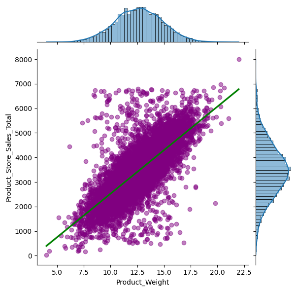

```python
# Scatter plot with regression line and histogram
plt.figure(figsize=[6, 4])
#sns.regplot(x=data.Product_Weight, y=data.Product_Store_Sales_Total,
#            scatter_kws={'color': 'purple', 'alpha': 0.5},
#            line_kws={'color': 'Green'})

sns.jointplot(x=data.Product_Weight, y=data.Product_Store_Sales_Total, kind='reg',
            scatter_kws={'color': 'purple', 'alpha': 0.5},
            line_kws={'color': 'Green'})

plt.show()
```

**Insights**

- Positive Correlation: The cloud of purple data points clearly trends upwards from the bottom-left to the top-right. This visually confirms that as Product_Weight increases, Product_Store_Sales_Total also tends to increase.
- The linear regression line cuts through the center of the data cloud, indicating that the relationship between the weight and sales is linear.
- While some significant scatter is observed, the points are tight around the linear regression line. This is consistent with the 0.74 correlation seen in the heatmap.
- While the general rule "heavier means more sales" holds true, the increasing variability for heavier items suggests that other factors (like brand, category, or promotions) could be playing a role in determining the final sales for these larger products.

### Distribution of Product_Allocated_Area vs Product_Store_Sales_Total

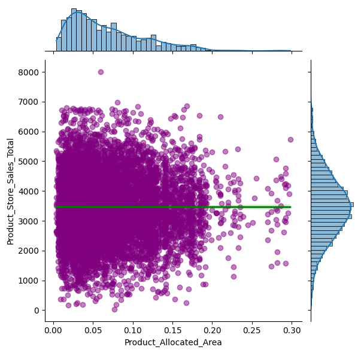

```python
# Scatter plot with regression line and histogram
plt.figure(figsize=[6, 4])

sns.jointplot(x=data.Product_Allocated_Area, y=data.Product_Store_Sales_Total, kind='reg',
            scatter_kws={'color': 'purple', 'alpha': 0.5},
            line_kws={'color': 'Green'})

plt.show()
```

**Insights**

- The correlation heatmap previously suggested no meaningful linear relationship between Product_Allocated_Area and Product_Store_Sales_Total. This is confirmed by the above plot.
- The purple data points form a shapeless, and somewhat rectangular cloud with no upward or downward trend. The points are widely scattered across the entire range of sales values, regardless of the allocated area.
- The solid green regression line is almost perfectly flat (horizontal). A horizontal line means that as the value on the x-axis (Product_Allocated_Area) increases, the predicted value on the y-axis (Product_Store_Sales_Total) does not change. This is the textbook graphical representation of a zero correlation.
- The data points are heavily concentrated on the left side of the plot, where the Product_Allocated_Area is low. As you move to the right (larger allocated area), the data points become much sparser.
- This is a very important insight for retail and category management. It suggests that strategies like "giving a product a bigger display to boost its sales" may be ineffective. The decision to allocate more space should likely be based on other factors, such as a product's existing high performance, promotional activities, or strategic importance, rather than being used as a tool to force high performance.
- Product_Allocated_Area would probably be a very poor feature to model predicted sales and could be considered for removal from the model without sacrificing accuracy.

### Distribution of Product_MRP vs Product_Store_Sales_Total

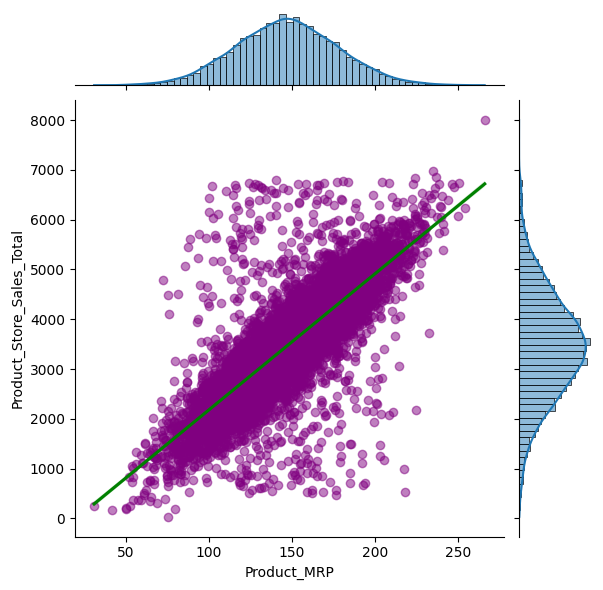

```python
# Scatter plot with regression line and histogram
plt.figure(figsize=[6, 4])

sns.jointplot(x=data.Product_MRP, y=data.Product_Store_Sales_Total, kind='reg',
            scatter_kws={'color': 'purple', 'alpha': 0.5},
            line_kws={'color': 'Green'})

plt.show()
```

### Product_Type vs Revenue

```python
# Sort the Product_Type by Product_Store_Sales_Total
data_product_type_revenue = data.groupby('Product_Type')['Product_Store_Sales_Total'].sum().sort_values().reset_index()
data_product_type_revenue
```

|  | Product_Type | Product_Store_Sales_Total |
| --- | --- | --- |
| 0 | Seafood | 272404.04 |
| 1 | Breakfast | 362130.41 |
| 2 | Starchy Foods | 518774.45 |
| 3 | Others | 541496.30 |
| 4 | Hard Drinks | 625814.62 |
| 5 | Breads | 714942.24 |
| 6 | Soft Drinks | 1797044.72 |
| 7 | Meat | 2129211.94 |
| 8 | Health and Hygiene | 2163707.21 |
| 9 | Canned | 2300082.71 |
| 10 | Baking Goods | 2452986.00 |
| 11 | Household | 2564740.17 |
| 12 | Frozen Foods | 2809980.83 |
| 13 | Dairy | 2811918.04 |
| 14 | Snack Foods | 3988996.95 |
| 15 | Fruits and Vegetables | 4300833.27 |

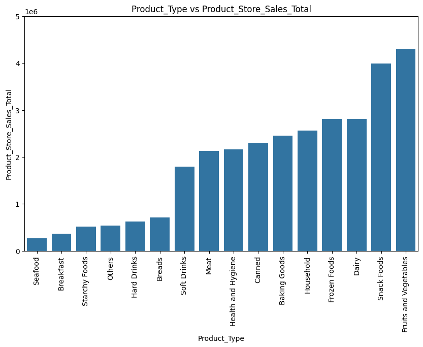

```python
# Barplot data_product_type_revenue.Product_Type vs data_product_type_revenue.Product_Store_Sales_Total
plt.figure(figsize=(10, 6))
sns.barplot(x=data_product_type_revenue.Product_Type, y=data_product_type_revenue.Product_Store_Sales_Total)
plt.xticks(rotation=90)
plt.ylim(0, 5000000)
plt.xlabel('Product_Type')
plt.ylabel('Product_Store_Sales_Total')
plt.title('Product_Type vs Product_Store_Sales_Total')
plt.show()
```

**Insights**

- The above table and barplots, show clearly which product categories are the most and least significant contributors to the store's total revenue.
- We can probably categorize them into:
  - Tier 1 (generating revenue > 3.5 Million)
    - Fruits & Vegetables, Snack Foods
    - Responsible for a huge portion of total sales. These also had the highest product counts. There might be a strong correlation between product variety/volume and total sales.
  - Tier 2 (generating revenue between 2 Million - 3 Million)
    - Dairy, Frozen Foods, Household, Baking Goods, Canned,Health and Hygiene,Meat.
    - This is a broad and significant tier.
    - The sales figures are very close for "Dairy" and "Frozen Foods," making them equally important.
    - "Household" and "Health and Hygiene" also demonstrate that non-food items are very significant revenue drivers.
  - Tier 3 (Mid-level revenue less than 2 Million)
    - Soft drinks sits in its own tier.
    - We saw that it had relatively high product count but sales are lower than food and household categories.
  - Tier 4 (Miscellaneous with revenue less than 1 Million)
    - Breads, Hard Drinks, Others, Starchy Foods, Breakfast, Seafood
    - Seafood was the lowest-performing category at 272k.
- Business Implications
  - Resource Allocation: Marketing budgets, promotional activities, and prime shelf space (like end caps and front-of-store displays) should be heavily focused on the Tier 1 and Tier 2 categories to maximize returns.
  - Growth Opportunities: Categories in Tier 3 and Tier 4 could be analyzed for growth potential.
  - Profitability Analysis: While this chart shows revenue, the next step would be to analyze profitability (sales minus cost of goods sold). A high-revenue category like "Snack Foods" might have lower profit margins than a smaller category like "Health and Hygiene."

### Product_Sugar_Content vs Revenue

```python
# Sort the Product_Sugar_Content by Product_Store_Sales_Total
data_sugar_content_revenue = data.groupby('Product_Sugar_Content')['Product_Store_Sales_Total'].sum().sort_values().reset_index()
data_sugar_content_revenue
```

|  | Product_Sugar_Content | Product_Store_Sales_Total |
| --- | --- | --- |
| 0 | reg | 394043.13 |
| 1 | No Sugar | 5269943.68 |
| 2 | Regular | 7867671.29 |
| 3 | Low Sugar | 16823405.80 |

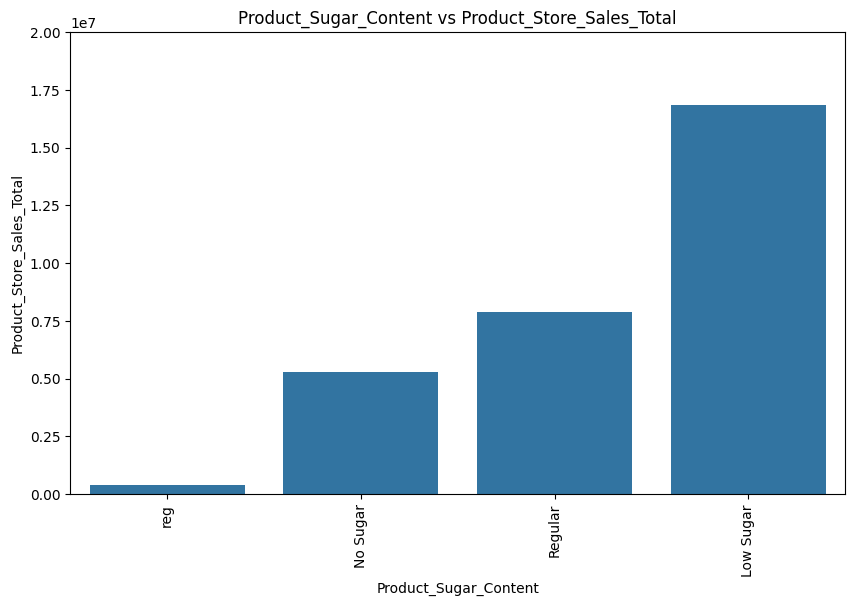

```python
# Barplot data_sugar_content_revenue.Product_Sugar_Content vs data_sugar_content_revenue.Product_Store_Sales_Total
plt.figure(figsize=(10, 6))
sns.barplot(x=data_sugar_content_revenue.Product_Sugar_Content, y=data_sugar_content_revenue.Product_Store_Sales_Total)
plt.xticks(rotation=90)
plt.ylim(0, 20000000)
plt.xlabel('Product_Sugar_Content')
plt.ylabel('Product_Store_Sales_Total')
plt.title('Product_Sugar_Content vs Product_Store_Sales_Total')
plt.show()
```

**Insights**

- We saw in previously that "Low Sugar" was the most numerous product type. This chart confirms it and also translates directly into highest sales revenue.
- The "Regular" and "reg" data inconsistency is also reflected here and probably should be combined.
- "Low Sugar" products generated over 16.8 million in sales, which is more than the combined sales of all other categories.
- There is a distinct hierarchy in revenue generation based on sugar content:
  - Low Sugar: 16.82 million
  - Regular: 7.87 million
  - No Sugar: 5.27 million
  - reg: 0.39 million (approximately 394k)
- "Low Sugar" products sell more than double the amount of "Regular" products.
- "Regular" products, in turn, sell significantly more than "No Sugar" products.
- The "reg" category is almost negligible in terms of sales revenue compared to the others.
- Business Implications
  - Market Trend: The data strongly suggests a powerful market trend towards "Low Sugar" options. Consumers are not only presented with more low-sugar choices, but they are also spending the most money on them. This indicates high demand for healthier or "diet" alternatives.
  - Strategic Alignment: The company's product assortment, which is heavily skewed towards "Low Sugar" items, is perfectly aligned with consumer spending patterns. This is a sign of a successful strategy that meets market demand.
  - Revenue Focus: From a revenue perspective, the "Low Sugar" product segment is the most critical to the business. Marketing campaigns, promotions, and new product development should likely continue to focus on this lucrative category.
  - Data Cleaning: The "reg" category continues to be a minor but persistent data quality issue that should be addressed by mapping it to "Regular" for all future analyses.

### Store_Id vs Revenue

```python
# Sort the Store_Id by Product_Store_Sales_Total
data_store_id_revenue = data.groupby('Store_Id')['Product_Store_Sales_Total'].sum().sort_values().reset_index()
data_store_id_revenue
```

|  | Store_Id | Product_Store_Sales_Total |
| --- | --- | --- |
| 0 | OUT002 | 2030909.72 |
| 1 | OUT001 | 6223113.18 |
| 2 | OUT003 | 6673457.57 |
| 3 | OUT004 | 15427583.43 |

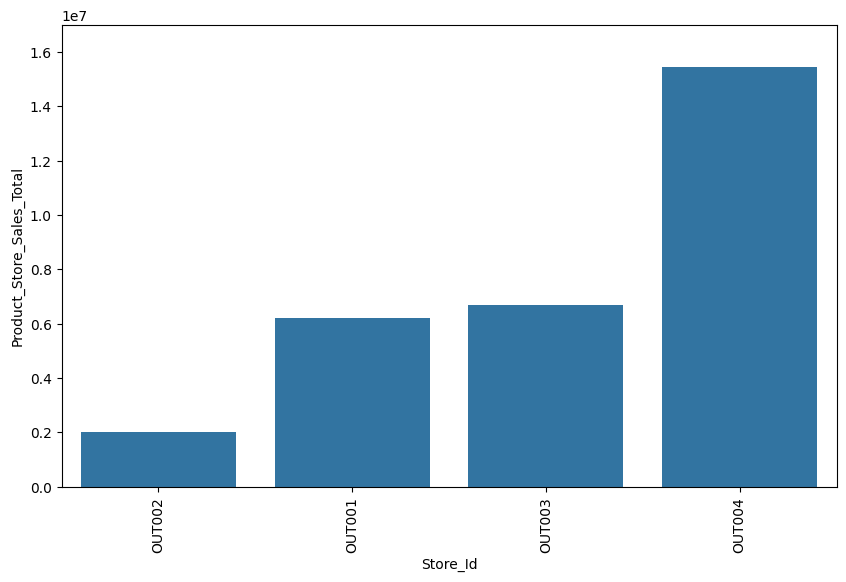

```python
# Barplot data_store_id_revenue.Store_Id vs data_sugar_content_revenue.Product_Store_Sales_Total
plt.figure(figsize=(10, 6))
sns.barplot(x=data_store_id_revenue.Store_Id, y=data_store_id_revenue.Product_Store_Sales_Total)
plt.xticks(rotation=90)
plt.ylim(0, 17000000)
plt.xlabel('Store_Id')
plt.ylabel('Product_Store_Sales_Total')
```

**Insights**

- Previously we had seen that OUT004 had larger counts than the others. This chart explains it - high volume transactions directly translates to dominant sales performance.
- OUT004 is not just a busy store but also the highest grossing store by a large margin compared to others.
- We can once again categorize the stores into three categories based on sales:
  - Tier 1: OUT004
  - Tier 2: OUT003 & OUT001
  - Tier 3: OUT002
- Business Implications
  - Store Strategy: The company is effectively running two different business models: the massive-scale operation at OUT004 and the more standard supermarket format at the other three locations. Strategies and performance metrics cannot be one-size-fits-all.
  - Performance Benchmarking: It might be misleading to benchmark the performance of OUT002 against OUT004. Performance for OUT001, OUT002, and OUT003 should be compared against each other.
  - Resource Allocation: OUT004 is the company's cash cow. It warrants significant investment to maintain its performance. Conversely, OUT002 represents either a problem to be fixed (e.g., through renovation, new marketing) or a candidate for divestment if the market cannot support higher sales.

### Store_Location_City_Type vs Revenue

```python
# Sort the Store_Location_City_Type by Product_Store_Sales_Total
data_city_type_revenue = data.groupby('Store_Location_City_Type')['Product_Store_Sales_Total'].sum().sort_values().reset_index()
data_city_type_revenue
```

|  | Store_Location_City_Type | Product_Store_Sales_Total |
| --- | --- | --- |
| 0 | Tier 3 | 2030909.72 |
| 1 | Tier 1 | 6673457.57 |
| 2 | Tier 2 | 21650696.61 |

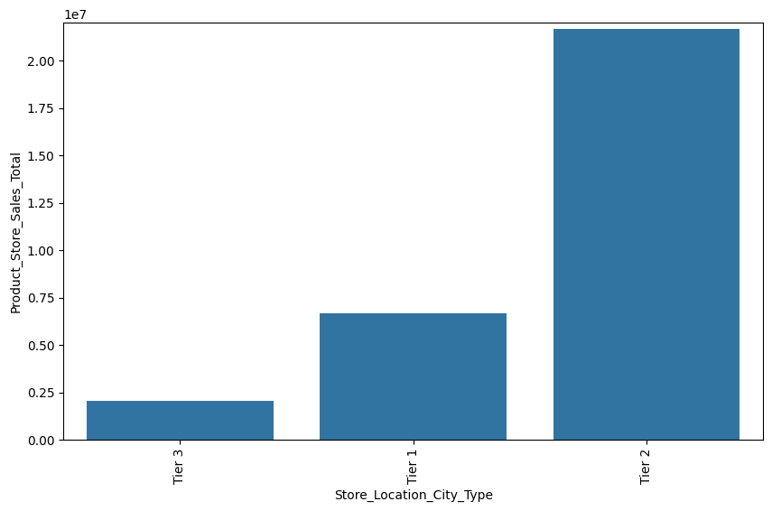

```python
# Barplot data_city_type_revenue.Store_Location_City_Type vs data_city_type_revenue.Product_Store_Sales_Total
plt.figure(figsize=(10, 6))
sns.barplot(x=data_city_type_revenue.Store_Location_City_Type, y=data_city_type_revenue.Product_Store_Sales_Total)
plt.xticks(rotation=90)
plt.ylim(0, 22000000)
plt.xlabel('Store_Location_City_Type')
plt.ylabel('Product_Store_Sales_Total')
```

**Insights**

- The plot reveals a huge disparity in sales performance, with one city tier massively outperforming the others.
- Tier 2 locations are the undisputed revenue powerhouse, generating over 21.6 million in sales. This is more than triple the sales of Tier 1 cities and over ten times the sales of Tier 3 cities.
- Tier 1 locations form the middle tier, with a respectable 6.67 million in total sales. While this is significantly lower than Tier 2, it is still a substantial amount of revenue.
- Tier 3 locations contribute the least to total sales, bringing in just over 2.0 million
- There is data imbalance with Tier 2 city having the most records.
- Business Implications
  - Geographic Strategy: The company's business is overwhelmingly concentrated in Tier 2 cities. Their success in these cities is the primary driver of the company's overall revenue.
  - Market Potential: The lower sales in Tier 1 and Tier 3 could represent untapped market potential and hence an improvement opportunity.
  - Risk Concentration: The heavy reliance on Tier 2 cities for revenue represents a concentration risk. Any negative shifts specifically affecting Tier 2 cities would have a disproportionately large impact on the company's bottom line. It may be wise to diversify among the tiers.

### Store_Type vs Revenue

```python
#Sort the Store_Type by Product_Store_Sales_Total
data_store_type_revenue = data.groupby('Store_Type')['Product_Store_Sales_Total'].sum().sort_values().reset_index()
data_store_type_revenue
```

|  | Store_Type | Product_Store_Sales_Total |
| --- | --- | --- |
| 0 | Food Mart | 2030909.72 |
| 1 | Supermarket Type1 | 6223113.18 |
| 2 | Departmental Store | 6673457.57 |
| 3 | Supermarket Type2 | 15427583.43 |

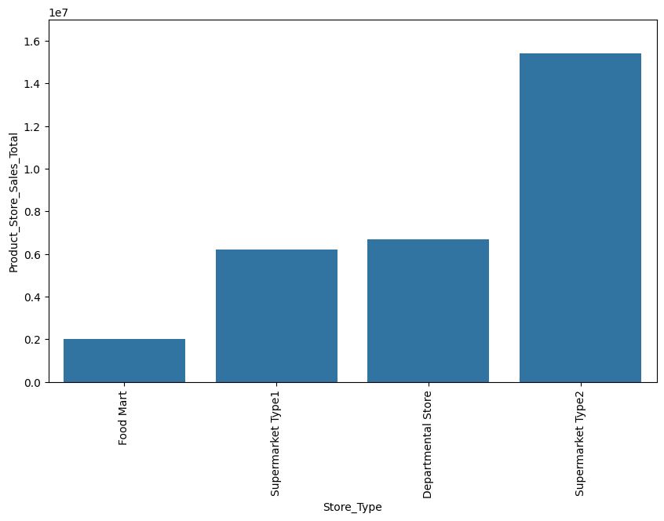

```python
#Plot
plt.figure(figsize=(10, 6))
sns.barplot(x=data_store_type_revenue.Store_Type, y=data_store_type_revenue.Product_Store_Sales_Total)
plt.xticks(rotation=90)
plt.ylim(0, 17000000)
plt.xlabel('Store_Type')
plt.ylabel('Product_Store_Sales_Total')
```

**Insights**

- The plot clearly illustrates that one store format is overwhelmingly responsible for the majority of the company's sales revenue (Supermarket Type2).
- We can classify these into three tiers:
  - Tier 1: (Supermarket Type2)
    - Supermarket Type2 is the clear leader, generating over $15.4 million in sales.
    - It generated more sales than the "Supermarket Type1" and "Departmental Store" formats combined.
  - Tier 2: (Supermarket Type1 & Departmental Store)
    - This tier consists of two formats with very similar and substantial sales figures (6.67 Million and 6.22 Million)
  - Tier 3: (Food Mart)
    - Food Mart is the lowest-performing format, with just over 2.0 million in sales.
- Business Implications
  - Format Strategy: The company's success is heavily dependent on its "Supermarket Type2" format. Future growth likely hinges on successfully opening more stores of this type.
  - Portfolio Management: The company is probably managing a diverse portfolio of store formats, each serving a different purpose.
    - Supermarket Type2: The growth orientation.
    - Supermarket Type1 / Departmental Store: Stable, profitable core business.
    - Food Mart: A convenience-oriented or niche market.
  - Profitability Analysis: The next logical step would be to analyze the profitability of each format. While "Supermarket Type2" has the highest sales, it may also have the highest operating costs. The smaller "Food Mart" might have a higher profit margin even if its total profit is lower.

### Store_Size vs Revenue

```python
#Sort the Store_Size by Product_Store_Sales_Total
data_store_size_revenue = data.groupby('Store_Size')['Product_Store_Sales_Total'].sum().sort_values().reset_index()
data_store_size_revenue
```

|  | Store_Size | Product_Store_Sales_Total |
| --- | --- | --- |
| 0 | Small | 2030909.72 |
| 1 | High | 6223113.18 |
| 2 | Medium | 22101041.00 |

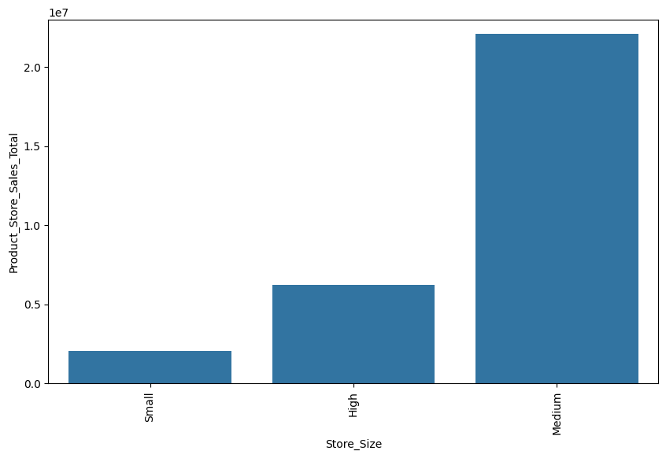

```python
#plot
plt.figure(figsize=(10, 6))
sns.barplot(x=data_store_size_revenue.Store_Size, y=data_store_size_revenue.Product_Store_Sales_Total)
plt.xticks(rotation=90)
plt.ylim(0, 23000000)
plt.xlabel('Store_Size')
plt.ylabel('Product_Store_Sales_Total')
```

**Insights**

- The plot clearly shows that "Medium" sized stores are outperforming the others.
- Medium sized stores are generating over 22.1 million in sales.
- High sized stores are generating around 6.2 million in sales. This is counter-intuitive.
- Small sized stores are the lowest performers with just over 2 million in sales.
- Business Implications
  - The "Medium" Format is Key: The company's most successful format falls under the "Medium" size classification. This is their strategic sweet spot, probably representing the best combination of location, product assortment, and customer traffic.
  - Strategy is Not Uniform: The company is not just running "small, medium, and large" stores in a simple sense. It is running:
    - A portfolio of highly successful "Medium" stores (including a hyper-successful flagship).
    - A single "High" sized store with moderate success.
    - A single "Small" convenience-style store with the lowest sales.

### Distribution of Store_ID vs Product_Store_Sales_Total

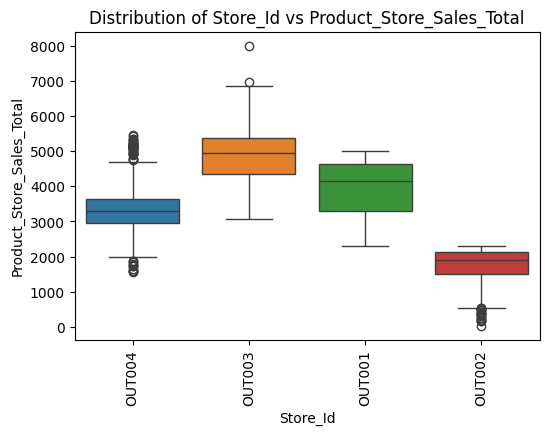

```python
#Boxplot Store_Id vs Product_Store_Sales_Total
plt.figure(figsize=[6, 4])

sns.boxplot(data=data, x="Store_Id", y="Product_Store_Sales_Total", hue="Store_Id")
plt.xticks(rotation=90)
plt.title("Distribution of Store_Id vs Product_Store_Sales_Total")
plt.xlabel("Store_Id")
plt.ylabel("Product_Store_Sales_Total")

plt.show()
```

**Insights**

- OUT003:
  - Highest median sales: A typical product sold at this store has the highest sale value.
  - This store sells both high and low revenue items and the average is very high.
  - Has a few outliers - maybe indicating some very successful products
- OUT001:
  - Second highest median sales.
  - Very wide distribution: Probably sells very low revenue to very high revenue items.
  - No outliers are depicted in the graph.
- OUT004:
  - Third highest median sales.
  - Tight distribution: Sales are consistent and predictable.
  - Large cluster of outliers observed above and below the main distribution.
- OUT002:
  - Lowest median sales
  - Tight distribution similar to OUT004.
  - Many low end outliers - emphasizing low-priced, quick purchase items.

Business Insights:

- OUT003 is the best store for high per-item revenue, while OUT004 is the best for high total volume.
- The outliers at OUT004 and OUT002 suggest these stores have a core range of products with very consistent sales, and anything outside that range is an exception. In contrast, the wider distributions at OUT001 and OUT003 suggest that a broad range of sales performance is normal for them.
- The four stores probably operate on different business models.

### Distribution of Store_Size vs Product_Store_Sales_Total

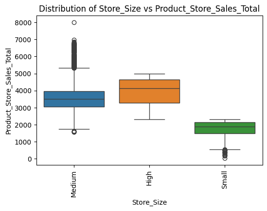

```python
#Boxplot Store_Size vs Product_Store_Sales_Total
plt.figure(figsize=[6, 4])

sns.boxplot(data=data, x="Store_Size", y="Product_Store_Sales_Total", hue="Store_Size")
plt.xticks(rotation=90)
plt.title("Distribution of Store_Size vs Product_Store_Sales_Total")
plt.xlabel("Store_Size")
plt.ylabel("Product_Store_Sales_Total")

plt.show()
```

**Insights**

- The plot reveals an unexpected observation - The "High" sized stores have highest average product sales. This is followed by "Medium" sized and "Small" sized stores.
- Previously, we had noticed that "Medium" sized stores were dominant in total sales.
- "High" sized stores:
  - The median is the highest (greater than 4000)
  - The distribution is wide and probably indicates sales of low to high revenue products.
  - No outliers are noticed
- "Medium" sized stores:
  - The median is the second highest (greater than 3000)
  - Outliers are noticed at both the top and bottom (especially the top).
  - While the "Medium" size category has the highest total sales, on a per-product basis, the typical sale in a "Medium" store is lower than in a "High" store.
- "Small" Sized stores:
  - The median is the lowest (less than 2000)
  - The distribution is compact.
  - We notice a cluster of outliers towards the low-end.
- Business Insights:
  - Total Sales vs. Per-Item Sales: This chart provides the critical distinction between total revenue and per-item revenue.
    - "Medium" stores win on TOTAL sales (due to high volume).
    - "High" stores win on PER-ITEM sales (due to higher-value products).

### Distribution of Product_Type vs Product_Weight

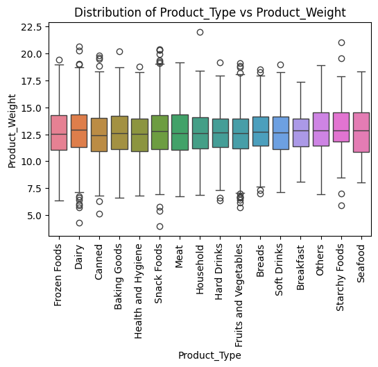

```python
#Boxplot Product_Type vs Product_Weight
plt.figure(figsize=[6, 4])

sns.boxplot(data=data, x="Product_Type", y="Product_Weight", hue="Product_Type")
plt.xticks(rotation=90)
plt.title("Distribution of Product_Type vs Product_Weight")
plt.xlabel("Product_Type")
plt.ylabel("Product_Weight")

plt.show()
```

### Distribution of Product_Weight vs Product_Sugar_Content

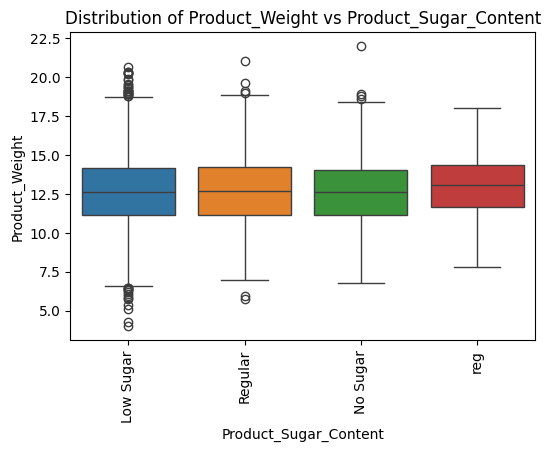

```python
#Boxplot of Product_Weight vs Product_Sugar_Content
plt.figure(figsize=[6, 4])

sns.boxplot(data=data, x="Product_Sugar_Content", y="Product_Weight", hue="Product_Sugar_Content")
plt.xticks(rotation=90)
plt.title("Distribution of Product_Weight vs Product_Sugar_Content")
plt.xlabel("Product_Sugar_Content")
plt.ylabel("Product_Weight")

plt.show()
```

**Insights**

- The plot above shows a lack of difference in the weight distribution among products with differing sugar content. It is once again suspiciously identical.
- The median weight for all four categories is almost the same, hovering right around 12.5.
- Three categories show outliers (except reg)
- The "reg" category though plotted separate has a very similar weight distribution to the remaining.
- I think the dataset has been manipulated to add missing values and hence the median is being pulled towards 12.5

### Product_Sugar_Content vs Product_Type Analysis

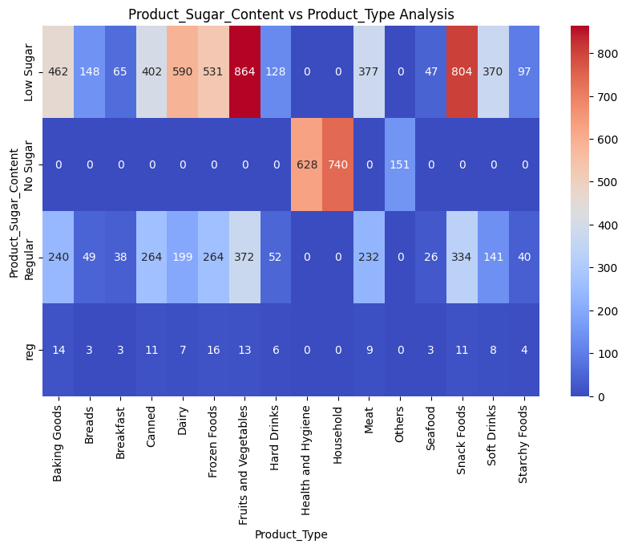

```python
#Plot a heatmap of Product_Sugar_Content vs Product_Type Analysis
plt.figure(figsize=(10, 6))
sns.heatmap(
    pd.crosstab(data["Product_Sugar_Content"], data["Product_Type"]),
    annot=True,
    fmt="g",
    cmap="coolwarm",
)
plt.ylabel("Product_Sugar_Content")
plt.xlabel("Product_Type")
plt.title("Product_Sugar_Content vs Product_Type Analysis")
plt.show()
```

**Insights**

### Store_Id vs Product_Type Analysis

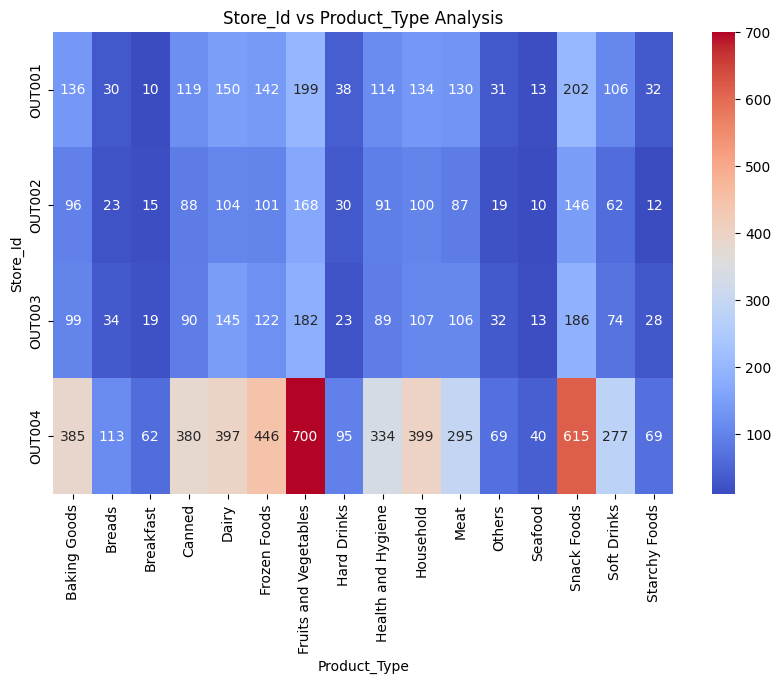

```python
#Plot a heatmap of Store_Id vs Product_Type
plt.figure(figsize=(10, 6))
sns.heatmap(
    pd.crosstab(data["Store_Id"], data["Product_Type"]),
    annot=True,
    fmt="g",
    cmap="coolwarm",
)
plt.ylabel("Store_Id")
plt.xlabel("Product_Type")
plt.title("Store_Id vs Product_Type Analysis")
plt.show()
```

### Product_MRP vs Product_Type Analysis

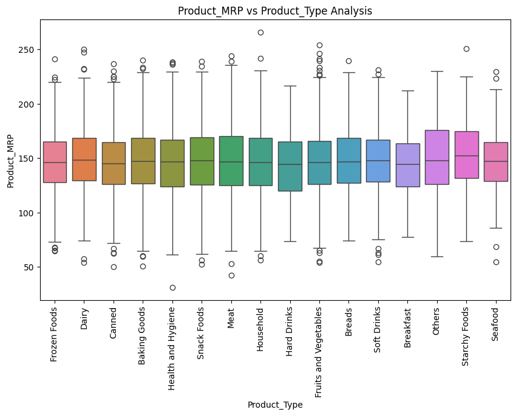

```python
#Plot a boxplot of Product_MRP vs Product_Type
plt.figure(figsize=(10, 6))
sns.boxplot(data=data, x="Product_Type", y="Product_MRP", hue="Product_Type")
plt.xticks(rotation=90)
plt.ylabel("Product_MRP")
plt.xlabel("Product_Type")
plt.title("Product_MRP vs Product_Type Analysis")
plt.show()
```

**Insights**

- Median price for almost all categories are in the 140-150 range.
- The company probably uses a standardized, tiered pricing strategy that is applied broadly across its product portfolio.
- Few categories have slightly different pricing profiles:
  - "Starchy Foods" and "Others" appear to have a slightly higher median price
  - "Canned" has a slightly lower median price compared to its immediate neighbors.
- Outliers are noticed on the low end and also the high end in many categories.
- Business Insights:
  - Portfolio-Wide Pricing Strategy: The company applies a consistent, tiered pricing architecture across its entire range of products. This simplifies pricing management and creates a predictable price perception for customers.
  - Margin Management: This strategy suggests that profit margins might vary significantly between categories. If a high-cost category like "Meat" is subject to the same pricing structure as a lower-cost category like "Snack Foods," their profitability profiles will be very different.
  - Each category contains a mix of products that fit into the company's predefined low, standard, and premium price tiers.

### Product_MRP vs Store_Id Analysis

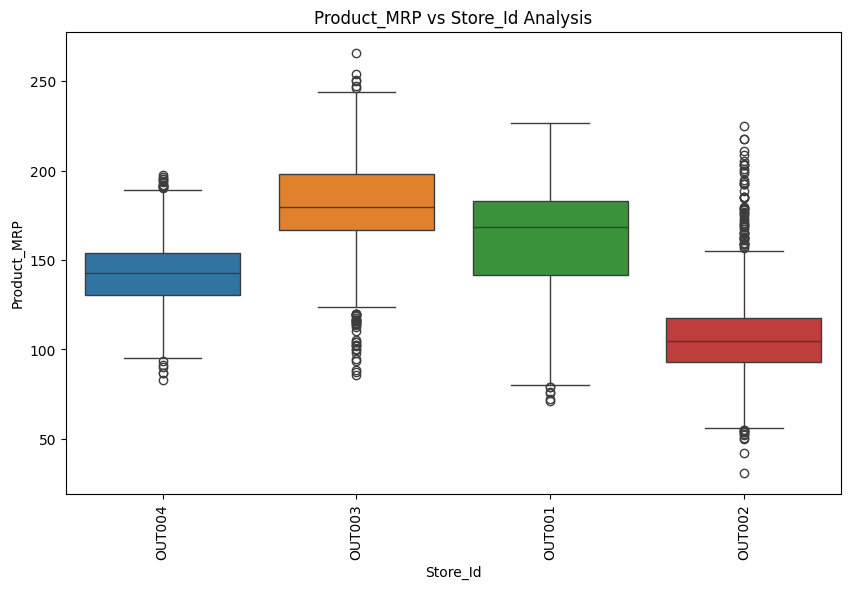

```python
#Boxplot of Product_MRP vs Store_Id
plt.figure(figsize=(10, 6))
sns.boxplot(data=data, x="Store_Id", y="Product_MRP", hue="Store_Id")
plt.xticks(rotation=90)
plt.ylabel("Product_MRP")
plt.xlabel("Store_Id")
plt.title("Product_MRP vs Store_Id Analysis")
plt.show()
```

### Individual Store Analysis

#### OUT001

```python
#Statistical description of data where Store_ID is OUT001
data[data['Store_Id'] == 'OUT001'].describe(include="all").T
```

|  | count | unique | top | freq | mean | std | min | 25% | 50% | 75% | max |
| --- | --- | --- | --- | --- | --- | --- | --- | --- | --- | --- | --- |
| Product_Id | 1586 | 1586 | NC7187 | 1 | NaN | NaN | NaN | NaN | NaN | NaN | NaN |
| Product_Weight | 1586.0 | NaN | NaN | NaN | 13.458865 | 2.064975 | 6.16 | 12.0525 | 13.96 | 14.95 | 17.97 |
| Product_Sugar_Content | 1586 | 4 | Low Sugar | 845 | NaN | NaN | NaN | NaN | NaN | NaN | NaN |
| Product_Allocated_Area | 1586.0 | NaN | NaN | NaN | 0.068768 | 0.047131 | 0.004 | 0.033 | 0.0565 | 0.094 | 0.295 |
| Product_Type | 1586 | 16 | Snack Foods | 202 | NaN | NaN | NaN | NaN | NaN | NaN | NaN |
| Product_MRP | 1586.0 | NaN | NaN | NaN | 160.514054 | 30.359059 | 71.35 | 141.72 | 168.32 | 182.9375 | 226.59 |
| Store_Id | 1586 | 1 | OUT001 | 1586 | NaN | NaN | NaN | NaN | NaN | NaN | NaN |
| Store_Establishment_Year | 1586.0 | NaN | NaN | NaN | 1987.0 | 0.0 | 1987.0 | 1987.0 | 1987.0 | 1987.0 | 1987.0 |
| Store_Size | 1586 | 1 | High | 1586 | NaN | NaN | NaN | NaN | NaN | NaN | NaN |
| Store_Location_City_Type | 1586 | 1 | Tier 2 | 1586 | NaN | NaN | NaN | NaN | NaN | NaN | NaN |
| Store_Type | 1586 | 1 | Supermarket Type1 | 1586 | NaN | NaN | NaN | NaN | NaN | NaN | NaN |
| Product_Store_Sales_Total | 1586.0 | NaN | NaN | NaN | 3923.778802 | 904.62901 | 2300.56 | 3285.51 | 4139.645 | 4639.4 | 4997.63 |

- OUT001:
  - Established in 1987
  - Located in a Tier 2 City
  - Supermarket Type 1 with high size.
  - Snack Foods was the highest sold Product_Type.
  - Low Sugar was the highest Product_Sugar_Content.
  - Revenue range was between 2300 and 4998

```python
# Total revenue generated by Store_ID OUT001
data[data['Store_Id'] == 'OUT001']['Product_Store_Sales_Total'].sum()
```

```
np.float64(6223113.18)
```

- Total revenue generated at OUT001 due to sales of goods = 6.2 Million

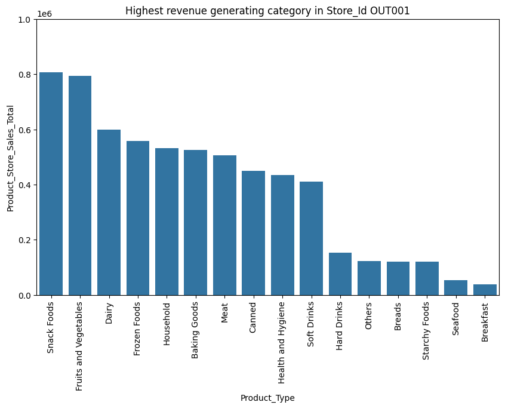

```python
#Highest revenue generating category in Store_Id OUT001
plot_data_OUT001 = (
    data.loc[data["Store_Id"] == "OUT001"]
    .groupby(["Product_Type"], as_index=False)["Product_Store_Sales_Total"]
    .sum()
)
plot_data_OUT001.sort_values(by="Product_Store_Sales_Total", ascending=False, inplace=True)

#plot Highest revenue generating category in Store_Id OUT001 in a barplot
plt.figure(figsize=(10, 6))
sns.barplot(x=plot_data_OUT001.Product_Type, y=  plot_data_OUT001.Product_Store_Sales_Total)
plt.xticks(rotation=90)
plt.ylim(0, 1000000)
plt.xlabel('Product_Type')
plt.ylabel('Product_Store_Sales_Total')
plt.title('Highest revenue generating category in Store_Id OUT001')
plt.show()
```

- "Snack Foods" and "Fruits and Vegetables" generate the highest revenue for OUT001 (about 800000 each).

#### OUT002

```python
#Statistical description of data where Store_ID is OUT002
data[data['Store_Id'] == 'OUT002'].describe(include="all").T
```

|  | count | unique | top | freq | mean | std | min | 25% | 50% | 75% | max |
| --- | --- | --- | --- | --- | --- | --- | --- | --- | --- | --- | --- |
| Product_Id | 1152 | 1152 | NC2769 | 1 | NaN | NaN | NaN | NaN | NaN | NaN | NaN |
| Product_Weight | 1152.0 | NaN | NaN | NaN | 9.911241 | 1.799846 | 4.0 | 8.7675 | 9.795 | 10.89 | 19.82 |
| Product_Sugar_Content | 1152 | 4 | Low Sugar | 658 | NaN | NaN | NaN | NaN | NaN | NaN | NaN |
| Product_Allocated_Area | 1152.0 | NaN | NaN | NaN | 0.067747 | 0.047567 | 0.006 | 0.031 | 0.0545 | 0.09525 | 0.292 |
| Product_Type | 1152 | 16 | Fruits and Vegetables | 168 | NaN | NaN | NaN | NaN | NaN | NaN | NaN |
| Product_MRP | 1152.0 | NaN | NaN | NaN | 107.080634 | 24.912333 | 31.0 | 92.8275 | 104.675 | 117.8175 | 224.93 |
| Store_Id | 1152 | 1 | OUT002 | 1152 | NaN | NaN | NaN | NaN | NaN | NaN | NaN |
| Store_Establishment_Year | 1152.0 | NaN | NaN | NaN | 1998.0 | 0.0 | 1998.0 | 1998.0 | 1998.0 | 1998.0 | 1998.0 |
| Store_Size | 1152 | 1 | Small | 1152 | NaN | NaN | NaN | NaN | NaN | NaN | NaN |
| Store_Location_City_Type | 1152 | 1 | Tier 3 | 1152 | NaN | NaN | NaN | NaN | NaN | NaN | NaN |
| Store_Type | 1152 | 1 | Food Mart | 1152 | NaN | NaN | NaN | NaN | NaN | NaN | NaN |
| Product_Store_Sales_Total | 1152.0 | NaN | NaN | NaN | 1762.942465 | 462.862431 | 33.0 | 1495.4725 | 1889.495 | 2133.6225 | 2299.63 |

```python
# Total revenue generated by Store_ID OUT002
data[data['Store_Id'] == 'OUT002']['Product_Store_Sales_Total'].sum()
```

```
np.float64(2030909.72)
```

- Total revenue generated at OUT002 due to sales of goods = 2.03 Million

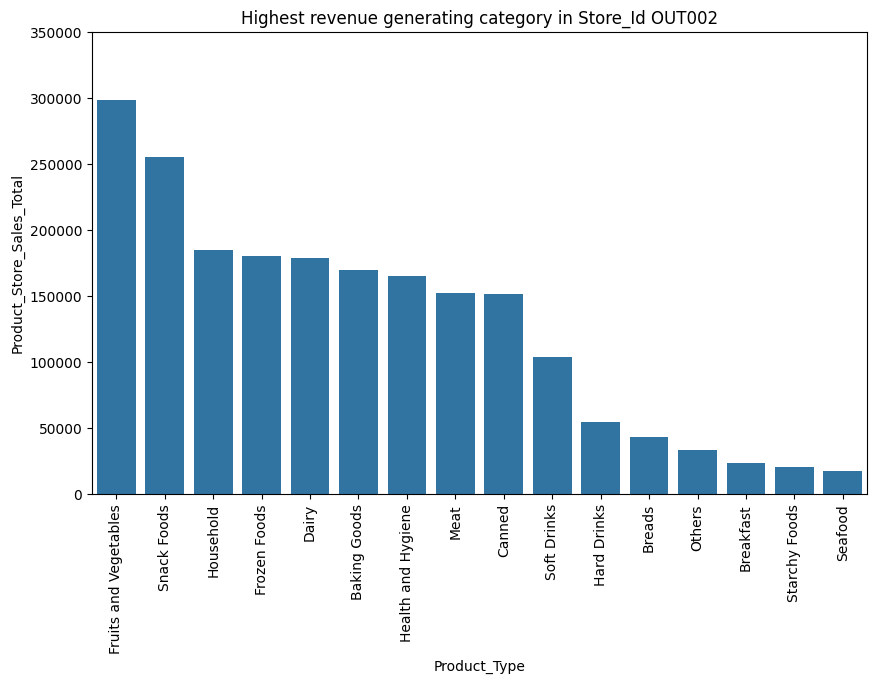

```python
#Highest revenue generating category in Store_Id OUT002
plot_data_OUT002 = (
    data.loc[data["Store_Id"] == "OUT002"]
    .groupby(["Product_Type"], as_index=False)["Product_Store_Sales_Total"]
    .sum()
)
plot_data_OUT002.sort_values(by="Product_Store_Sales_Total", ascending=False, inplace=True)

#plot Highest revenue generating category in Store_Id OUT002 in a barplot
plt.figure(figsize=(10, 6))
sns.barplot(x=plot_data_OUT002.Product_Type, y=  plot_data_OUT002.Product_Store_Sales_Total)
plt.xticks(rotation=90)
plt.ylim(0, 350000)
plt.xlabel('Product_Type')
plt.ylabel('Product_Store_Sales_Total')
plt.title('Highest revenue generating category in Store_Id OUT002')
plt.show()
```

#### OUT003

```python
#Statistical description of data where Store_ID is OUT003
data[data['Store_Id'] == 'OUT003'].describe(include="all").T
```

|  | count | unique | top | freq | mean | std | min | 25% | 50% | 75% | max |
| --- | --- | --- | --- | --- | --- | --- | --- | --- | --- | --- | --- |
| Product_Id | 1349 | 1349 | NC522 | 1 | NaN | NaN | NaN | NaN | NaN | NaN | NaN |
| Product_Weight | 1349.0 | NaN | NaN | NaN | 15.103692 | 1.893531 | 7.35 | 14.02 | 15.18 | 16.35 | 22.0 |
| Product_Sugar_Content | 1349 | 4 | Low Sugar | 750 | NaN | NaN | NaN | NaN | NaN | NaN | NaN |
| Product_Allocated_Area | 1349.0 | NaN | NaN | NaN | 0.068637 | 0.048708 | 0.004 | 0.031 | 0.057 | 0.094 | 0.298 |
| Product_Type | 1349 | 16 | Snack Foods | 186 | NaN | NaN | NaN | NaN | NaN | NaN | NaN |
| Product_MRP | 1349.0 | NaN | NaN | NaN | 181.358725 | 24.796429 | 85.88 | 166.92 | 179.67 | 198.07 | 266.0 |
| Store_Id | 1349 | 1 | OUT003 | 1349 | NaN | NaN | NaN | NaN | NaN | NaN | NaN |
| Store_Establishment_Year | 1349.0 | NaN | NaN | NaN | 1999.0 | 0.0 | 1999.0 | 1999.0 | 1999.0 | 1999.0 | 1999.0 |
| Store_Size | 1349 | 1 | Medium | 1349 | NaN | NaN | NaN | NaN | NaN | NaN | NaN |
| Store_Location_City_Type | 1349 | 1 | Tier 1 | 1349 | NaN | NaN | NaN | NaN | NaN | NaN | NaN |
| Store_Type | 1349 | 1 | Departmental Store | 1349 | NaN | NaN | NaN | NaN | NaN | NaN | NaN |
| Product_Store_Sales_Total | 1349.0 | NaN | NaN | NaN | 4946.966323 | 677.539953 | 3069.24 | 4355.39 | 4958.29 | 5366.59 | 8000.0 |

- OUT003:
  - Established in 1999
  - Located in a Tier 1 City
  - Departmental Store with medium size.
  - Snack Foods was the highest sold Product_Type.
  - Low Sugar was the highest Product_Sugar_Content.
  - Revenue range was between 3069 and 8000

```python
# Total revenue generated by Store_ID OUT003
data[data['Store_Id'] == 'OUT003']['Product_Store_Sales_Total'].sum()
```

```
np.float64(6673457.57)
```

- Total revenue generated at OUT003 due to sales of goods = 6.67 Million

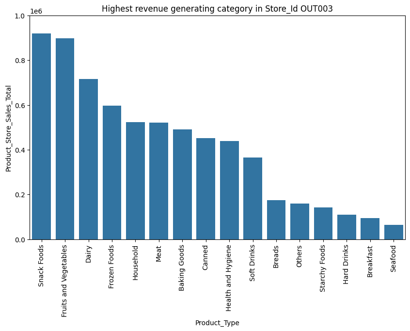

```python
#Highest revenue generating category in Store_Id OUT003
plot_data_OUT003 = (
    data.loc[data["Store_Id"] == "OUT003"]
    .groupby(["Product_Type"], as_index=False)["Product_Store_Sales_Total"]
    .sum()
)
plot_data_OUT003.sort_values(by="Product_Store_Sales_Total", ascending=False, inplace=True)

#plot Highest revenue generating category in Store_Id OUT003 in a barplot
plt.figure(figsize=(10, 6))
sns.barplot(x=plot_data_OUT003.Product_Type, y=  plot_data_OUT003.Product_Store_Sales_Total)
plt.xticks(rotation=90)
plt.ylim(0, 1000000)
plt.xlabel('Product_Type')
plt.ylabel('Product_Store_Sales_Total')
plt.title('Highest revenue generating category in Store_Id OUT003')
plt.show()
```

- "Snack Foods" and "Fruits and Vegetables" generate the highest revenue for OUT003 (about 900000 each).

#### OUT004

```python
#Statistical description of data where Store_ID is OUT004
data[data['Store_Id'] == 'OUT004'].describe(include="all").T
```

|  | count | unique | top | freq | mean | std | min | 25% | 50% | 75% | max |
| --- | --- | --- | --- | --- | --- | --- | --- | --- | --- | --- | --- |
| Product_Id | 4676 | 4676 | NC584 | 1 | NaN | NaN | NaN | NaN | NaN | NaN | NaN |
| Product_Weight | 4676.0 | NaN | NaN | NaN | 12.349613 | 1.428199 | 7.34 | 11.37 | 12.37 | 13.3025 | 17.79 |
| Product_Sugar_Content | 4676 | 4 | Low Sugar | 2632 | NaN | NaN | NaN | NaN | NaN | NaN | NaN |
| Product_Allocated_Area | 4676.0 | NaN | NaN | NaN | 0.069092 | 0.048584 | 0.004 | 0.031 | 0.056 | 0.097 | 0.297 |
| Product_Type | 4676 | 16 | Fruits and Vegetables | 700 | NaN | NaN | NaN | NaN | NaN | NaN | NaN |
| Product_MRP | 4676.0 | NaN | NaN | NaN | 142.399709 | 17.513973 | 83.04 | 130.54 | 142.82 | 154.1925 | 197.66 |
| Store_Id | 4676 | 1 | OUT004 | 4676 | NaN | NaN | NaN | NaN | NaN | NaN | NaN |
| Store_Establishment_Year | 4676.0 | NaN | NaN | NaN | 2009.0 | 0.0 | 2009.0 | 2009.0 | 2009.0 | 2009.0 | 2009.0 |
| Store_Size | 4676 | 1 | Medium | 4676 | NaN | NaN | NaN | NaN | NaN | NaN | NaN |
| Store_Location_City_Type | 4676 | 1 | Tier 2 | 4676 | NaN | NaN | NaN | NaN | NaN | NaN | NaN |
| Store_Type | 4676 | 1 | Supermarket Type2 | 4676 | NaN | NaN | NaN | NaN | NaN | NaN | NaN |
| Product_Store_Sales_Total | 4676.0 | NaN | NaN | NaN | 3299.312111 | 468.271692 | 1561.06 | 2942.085 | 3304.18 | 3646.9075 | 5462.86 |

- OUT004:
  - Established in 2009
  - Located in a Tier 2 City
  - Supermarket Type 2 with medium size.
  - Fruits and Vegetables was the highest sold Product_Type.
  - Low Sugar was the highest Product_Sugar_Content.
  - Revenue range was between 1560 and 5463.

```python
# Total revenue generated by Store_ID OUT004
data[data['Store_Id'] == 'OUT004']['Product_Store_Sales_Total'].sum()
```

```
np.float64(15427583.43)
```

- Total revenue generated at OUT004 due to sales of goods = 15 Million (Highest among all stores)

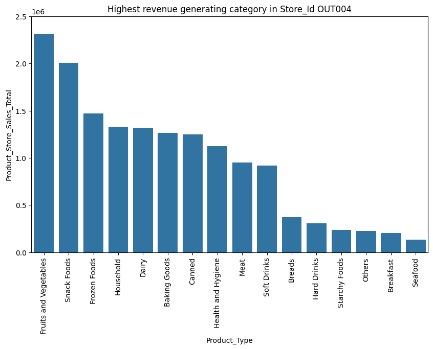

```python
#Highest revenue generating category in Store_Id OUT004
plot_data_OUT004= (
    data.loc[data["Store_Id"] == "OUT004"]
    .groupby(["Product_Type"], as_index=False)["Product_Store_Sales_Total"]
    .sum()
)
plot_data_OUT004.sort_values(by="Product_Store_Sales_Total", ascending=False, inplace=True)

#plot Highest revenue generating category in Store_Id OUT004 in a barplot
plt.figure(figsize=(10, 6))
sns.barplot(x=plot_data_OUT004.Product_Type, y=  plot_data_OUT004.Product_Store_Sales_Total)
plt.xticks(rotation=90)
plt.ylim(0, 2500000)
plt.xlabel('Product_Type')
plt.ylabel('Product_Store_Sales_Total')
plt.title('Highest revenue generating category in Store_Id OUT004')
plt.show()
```

- "Fruits and Vegetables" and "Snack Foods" generate the highest revenue for OUT004 (about 2300000 and 2000000 each).